# AI CA4 (Machine Learning) - Majid Faridfar

More details for `n_estimators` and `max_features`:

- `n_estimators`: This hyperparameter controls the number of decision trees in the random forest. Increasing the number of trees can lead to better performance, but also increases the computational cost and potential overfitting. The default value for this hyperparameter is 100, but it can be tuned based on the dataset and desired performance.
- `max_features`: This hyperparameter controls the number of features randomly selected at each split of a decision tree. The default value for classification tasks is "sqrt", which means the square root of the total number of features is used. Increasing this value can lead to more complex models with potentially better performance, but also increases the risk of overfitting. On the other hand, decreasing this value can lead to simpler models that are less prone to overfitting but may have lower performance.

```
Number of Decision Trees: 1
```

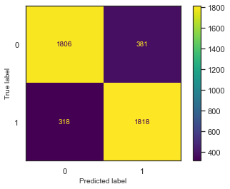

```
Number of Decision Trees: 2
```

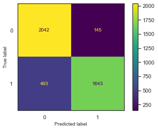

```
Number of Decision Trees: 3
```

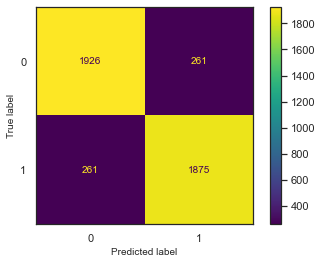

```
Number of Decision Trees: 4
```

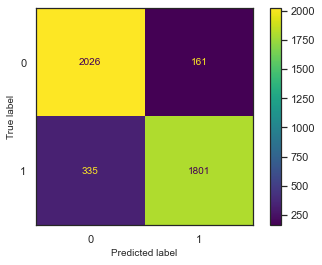

```
Number of Decision Trees: 5
```

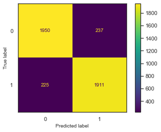

```
Number of Decision Trees: 6
```

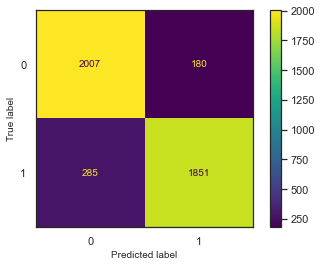

```
Number of Decision Trees: 7
```

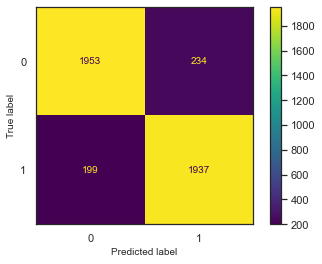

```
Number of Decision Trees: 8
```

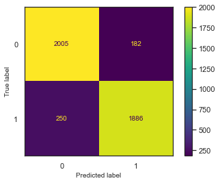

```
Number of Decision Trees: 9
```

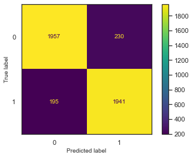

```
Number of Decision Trees: 10
```

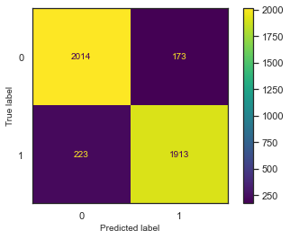

```
Number of Decision Trees: 11
```

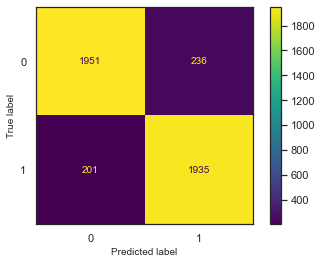

```
Number of Decision Trees: 12
```

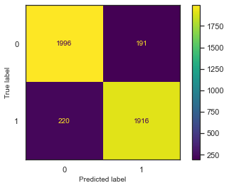

```
Number of Decision Trees: 13
```

[18 more figures not shown]

```python
from sklearn.metrics import ConfusionMatrixDisplay

rf_acc=[]

for i in range(1, 31):
    predicted_tmp=[]
    rf_i = RandomForestClassifier(n_estimators=i)
    rf_i.fit(x_train, y_train)
    y_pred_i = rf_i.predict(x_test)

    rf_acc.append(accuracy_score(y_test, y_pred_i))
    cm = confusion_matrix(y_test, y_pred_i)

    cm_display = ConfusionMatrixDisplay(cm, display_labels = [0,1])
    cm_display.plot()
    print("Number of Decision Trees:", i)
    plt.show()
```

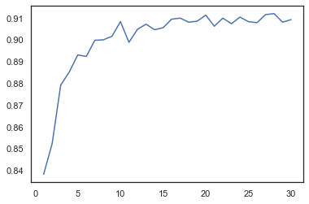

```python
x_arr=[i for i in range(1,31)]
plt.plot(x_arr, rf_acc)
plt.show()
```

As you can see, as the number of trees (`n_estimators`) increases, the `accuracy` increases, but as the number of these trees increases, the speed of growth of accuracy decreases.

```
Number of Decision Trees: 1
```

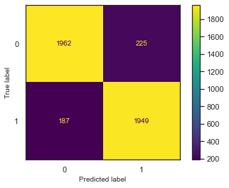

```
Number of Decision Trees: 2
```

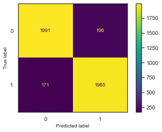

```
Number of Decision Trees: 3
```

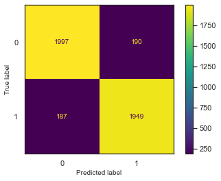

```
Number of Decision Trees: 4
```

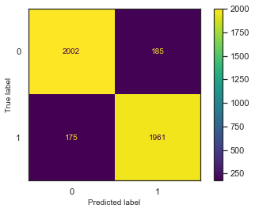

```
Number of Decision Trees: 5
```

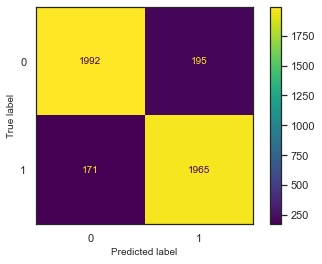

```
Number of Decision Trees: 6
```

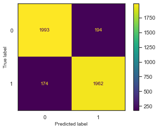

```
Number of Decision Trees: 7
```

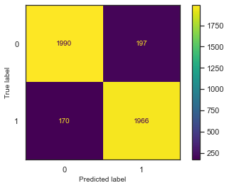

```
Number of Decision Trees: 8
```

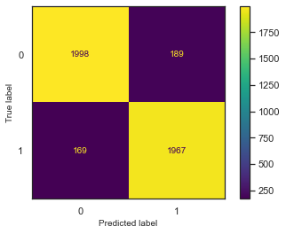

```
Number of Decision Trees: 9
```

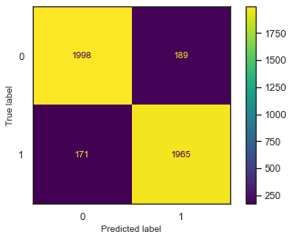

```
Number of Decision Trees: 10
```

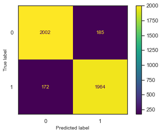

```
Number of Decision Trees: 11
```

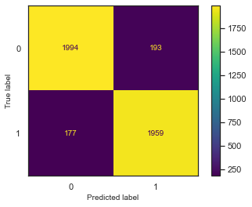

```
Number of Decision Trees: 12
```

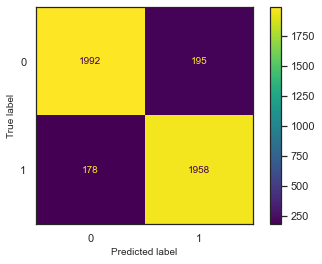

```
Number of Decision Trees: 13
```

[8 more figures not shown]

```python
rf_acc=[]

for i in range(1, 21):
    predicted_tmp=[]
    rf_i = RandomForestClassifier(max_features=i)
    rf_i.fit(x_train, y_train)
    y_pred_i = rf_i.predict(x_test)

    rf_acc.append(accuracy_score(y_test, y_pred_i))
    cm = confusion_matrix(y_test, y_pred_i)

    cm_display = ConfusionMatrixDisplay(cm, display_labels = [0,1])
    cm_display.plot()
    print("Number of Decision Trees:", i)
    plt.show()
```

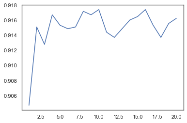

```python
x_arr=[i for i in range(1,21)]
plt.plot(x_arr, rf_acc)
plt.show()
```

**Compare result of Random Forest, with Desicion Trees.**

In terms of performance, Random Forests tend to perform better than Decision Trees on average, especially when the data is noisy or high-dimensional. However, there are some cases where Decision Trees can perform better, especially when the data is simple or the relationships between the features and the target variable are straightforward.

**What are variance and bias, and the relation?**

- **Bias** refers to the error that is introduced by approximating a real-world problem with a simpler model. A model with high bias tends to make strong assumptions about the data and may underfit the data. In other words, it is unable to capture the true underlying patterns in the data. High bias models are often too simple and lack the complexity needed to accurately model the data.
- **Variance**, on the other hand, refers to the error that is introduced by the model's sensitivity to small fluctuations or noise in the training data. A model with high variance tends to overfit the data, meaning that it fits the training data too closely and is unable to generalize well to new, unseen data. In other words, the model is too complex and captures both the signal and the noise in the data.

The relationship between bias and variance can be visualized using the bias-variance tradeoff. The tradeoff arises because increasing the complexity of a model (i.e., adding more parameters or increasing the size of the model) can reduce bias but increase variance, while decreasing the complexity of a model can reduce variance but increase bias.

The goal, is to find a balance between bias and variance that minimizes the overall error, which is known as the `generalization error`. A model that is too simple (i.e., high bias) will have a high error on both the training and testing data, while a model that is too complex (i.e., high variance) will have a low error on the training data but a high error on the testing data. The optimal model is one that has low bias and low variance, which means that it can accurately model the underlying patterns in the data without overfitting.

**Does dicision tree performs better, or random forest in terms of variance and bias?**

Random forests tend to perform better than decision trees in terms of variance and bias. While decision trees can be prone to high variance and bias, random forests are designed to reduce these issues by combining multiple decision trees and taking a random subset of features and data samples for each tree. Random forests are designed to reduce the variance and overfitting that can occur in decision trees.

For instance, you can see the variance is reduced in random forest:

```python
rf.fit(x_train, y_train)
dtc.fit(x_train, y_train)

print("Random Forest:", rf.feature_importances_.var())
print("Decision Tree:", dtc.feature_importances_.var())
```

```
Random Forest: 0.003364481192558064
Decision Tree: 0.01640289218489712
```

##### Gradient-boosting

**What is Gradient-boosting?**

Gradient Boosting is a machine learning technique used for building predictive models, especially in the context of `regression` and `classification` problems. It works by combining multiple weak learners (i.e., models that perform slightly better than random guessing) to create a strong learner (i.e., a model that performs well on the given task).

The general idea behind Gradient Boosting is to iteratively add new models to the ensemble, where each model is trained to correct the errors of the previous models. Specifically, the algorithm works as follows:

1. Initialize the ensemble with a simple model, such as a decision tree with only one split.
2. Train the model to predict the target variable.
3. Calculate the residuals (i.e., the differences between the predicted values and the actual values) for each observation in the training data.
4. Fit a new model to the residuals, with the goal of predicting the residuals more accurately than the previous model.
5. Add the new model to the ensemble, and update the predictions by adding the predictions of the new model multiplied by a learning rate (which controls the contribution of each model to the ensemble).
6. Repeat steps 3-5 until the ensemble reaches a desired level of performance, or until a stopping criterion is met.

The key idea behind Gradient Boosting is to use the gradient of the loss function with respect to the predictions of the previous models (i.e., the residuals) as a guide for fitting the new model. This allows the algorithm to focus on the areas where the previous models performed poorly, and to gradually improve the overall performance of the ensemble. Gradient Boosting is a powerful and flexible technique that can be used for a wide range of machine learning tasks. It has been shown to perform well on many benchmark datasets, and is widely used in industry and academia for building predictive models.

**What is difference between boosting tree and decision tree?**

Boosting and decision trees are two different concepts in machine learning, but they are often used together in the context of ensemble learning.

- **Boosting** is a general technique for improving the performance of machine learning algorithms by combining multiple weak learners into a single strong learner. The idea is to iteratively train new models that focus on the examples that were misclassified by the previous models, and to combine the predictions of all the models into a final prediction. Boosting can be used with many different types of weak learners, including decision trees.
- **Decision trees**, on the other hand, are a specific type of machine learning algorithm that can be used for both regression and classification problems. A decision tree is essentially a flowchart-like structure that recursively partitions the data into smaller subsets based on the values of the input variables. Each internal node of the tree represents a test on a single input variable, and each leaf node represents a prediction for the target variable.

The main difference between boosting and decision trees is that boosting is a technique for improving the performance of machine learning algorithms, while decision trees are a specific type of algorithm. Decision trees can be used as weak learners in boosting, but boosting can also be used with other types of weak learners, such as neural networks or support vector machines.

**What is XGBoost?**

XGBoost (eXtreme Gradient Boosting) is a popular implementation of the Gradient Boosting algorithm that is optimized for performance and scalability. It is widely used in industry and academia for a wide range of machine learning tasks, including regression, classification, and ranking. XGBoost is a powerful and flexible algorithm that can be used for a wide range of machine learning tasks. Its speed, accuracy, and scalability make it a popular choice in many applications, including recommendation systems, fraud detection, and image classification.

The basic idea behind XGBoost is similar to other Gradient Boosting algorithms, but it includes several key optimizations that make it faster and more accurate. Here are the main steps of the XGBoost algorithm:

1. **Initialize the model**: XGBoost starts with a single decision tree with a single leaf node, which represents the mean of the target variable.
2. **Calculate the gradients and hessians**: For each observation in the training data, XGBoost calculates the gradient and hessian of the loss function with respect to the predicted value. The gradient is the derivative of the loss function, and the hessian is the second derivative.
3. **Build a tree to fit the residuals**: XGBoost builds a decision tree to fit the residuals (i.e., the differences between the predicted values and the actual values). The tree is built using a greedy algorithm that recursively splits the data into subsets based on the values of the input variables.
4. **Add the tree to the model**: XGBoost adds the new tree to the model, and updates the predictions by adding the predictions of the new tree multiplied by a learning rate (which controls the contribution of each tree to the model).
5. Repeat steps 2-4 until the model reaches a desired level of performance, or until a stopping criterion is met.

In addition to these basic steps, XGBoost includes several key optimizations, such as:

- **Regularization**: XGBoost includes several types of regularization, such as L1 and L2 regularization, to prevent overfitting and improve generalization performance.
- **Parallel processing**: XGBoost uses parallel processing to speed up the training process, by splitting the data and the computations across multiple cores or nodes.
- **Tree pruning**: XGBoost prunes the decision trees to remove unnecessary branches and reduce the complexity of the model, which improves both speed and accuracy.

```
Accuracy: 0.9192690261392551
```

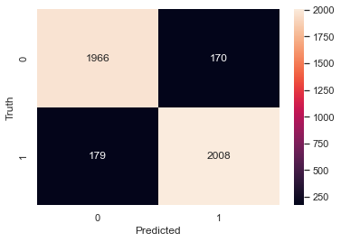

```python
from xgboost import XGBClassifier

xg = XGBClassifier(objective='multi:softmax', num_class=2)
xg.fit(x_train, y_train)

y_pred = xg.predict(x_test)

acc = accuracy_score(y_test, y_pred)
print("Accuracy:", accuracy_score(y_test, y_pred))

cm = confusion_matrix(y_test, y_pred)

sns.heatmap(cm, annot=True, fmt='d')
plt.xlabel('Predicted')
plt.ylabel('Truth')
```

As you can see, the accuracy of this method is higher than all the models we tested.

```python
xg_params = {
    'max_depth': [3, 4, 5],
    'learning_rate': [0.1, 0.01],
    'n_estimators': [100, 200],
    'gamma': [0, 0.1],
    'min_child_weight': [5]}

xg = XGBClassifier()
xg_grid = GridSearchCV(xg, xg_params, cv=5)

xg_grid.fit(x, y)

print("Logistic Regression best parameters:", xg_grid.best_params_)
print("Logistic Regression best score:", xg_grid.best_score_)
```

```
Logistic Regression best parameters: {'gamma': 0, 'learning_rate': 0.1, 'max_depth': 5, 'min_child_weight': 5, 'n_estimators': 200}
Logistic Regression best score: 0.9155603782186754
```